# The Office Report

### Check those empty squares!

Now that we talk about it, we wantes to know how balanced was the show in terms of gender equality. We cross referenced our original dataframe with a table containing the genders of the 30 main characters of the show, and dived into it hoping to answer our quesiton.

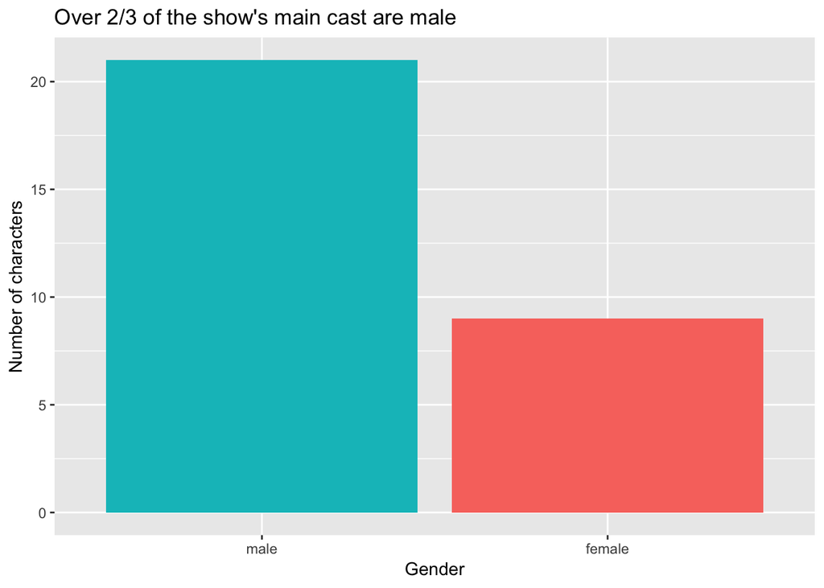

```r
gen <- read.csv(file="../Cubicles/Jose/main_cast_gender.csv", header=TRUE, sep=",")

ggplot(gen, aes(x=fct_infreq(gen$gender))) +
  geom_bar(aes(y=(..count..), fill = gender)) +
  labs(title = "Over 2/3 of the show's main cast are male",
       x = "Gender",
       y = "Number of characters") +
    theme(legend.position="none")
```

First, we found that over 66% of the cast throughout the series were male. Does this represent appropriately the professional setting in the USA? We’re not sure. However, this sets up a baseline for the next question: are dialogues proportional to the number of characters belonging to each gender?

```r
## Merge for number of dialogues
gen_dialogues <- merge(dialogues_by_char, gen, all.x = TRUE) %>%
  filter(gender %in% c('male', 'female')) %>%
  group_by(gender) %>%
  summarize(Freq = sum(Freq)) %>%
  arrange(-Freq)
```

```
## Error in merge(dialogues_by_char, gen, all.x = TRUE): object 'dialogues_by_char' not found
```

```r
plot1 <- ggplot(gen_dialogues, aes(x = reorder(gender, -Freq), y = Freq, fill = gender)) +
  geom_col() +
  labs(title = "Do females have more dialogues?", x = "Gender", y="Number of lines (in thousands)") +
  theme(legend.position="none")
```

```
## Error in ggplot(gen_dialogues, aes(x = reorder(gender, -Freq), y = Freq, : object 'gen_dialogues' not found
```

```r
## Merge for number of words
gen_words <- merge(words_by_char, gen, all.x = TRUE) %>%
  filter(gender %in% c('male', 'female')) %>%
  group_by(gender) %>%
  summarize(Freq = sum(Freq)) %>%
  arrange(-Freq)
```

```
## Error in merge(words_by_char, gen, all.x = TRUE): object 'words_by_char' not found
```

```r
plot2 <- ggplot(gen_words, aes(x = reorder(gender, -Freq), y = Freq, fill = gender)) +
  geom_col() +
  labs(title = "Who says more words?",
       x = "Gender",
       y = "Number of words (in thousands)") +
    theme(legend.position="none")
```

```
## Error in ggplot(gen_words, aes(x = reorder(gender, -Freq), y = Freq, fill = gender)): object 'gen_words' not found
```

```r
grid.arrange(plot1, plot2, ncol=2)
```

[output not shown]

```
## Error in arrangeGrob(...): object 'plot1' not found
```

It would be interesting to see how, as the series incorporated new characters, the proportion might have changed from season to season.

```r
dialogues_by_gen <- merge(dialogues_df, gen, all.x = TRUE) %>%
  filter(gender %in% c('male', 'female')) %>%
  group_by(season, gender) %>%
  summarize(Freq = n())
```

```
## Error in merge(dialogues_df, gen, all.x = TRUE): object 'dialogues_df' not found
```

```r
dialogues_by_gen$season <- as.factor(dialogues_by_gen$season)
```

```
## Error in is.factor(x): object 'dialogues_by_gen' not found
```

```r
ggplot(dialogues_by_gen, aes(x = season, y = Freq, fill = gender)) +
  geom_bar(position = "fill", stat = "identity") +
  labs(title = "The ratio of dialogues by gender remains constant through the seasons",
       x = "Season",
       y = "Percentage of lines") +
  scale_y_continuous(labels = scales::percent_format(accuracy = 1))
```

[output not shown]

```
## Error in ggplot(dialogues_by_gen, aes(x = season, y = Freq, fill = gender)): object 'dialogues_by_gen' not found
```

There was a clear evolution in the show, specially in terms of character development and changes in cast. In the competitive environment of sitcoms, shows must continually innovate to keep their rating levels, so we decided to take a look at ratings for the show.

```r
mydir <- "C:/Users/ganto/OneDrive/Documents/GitHub/InsideTheOffice/Cubicles/Antonio's Office"
surfdir <- "C:/Users/Antonio/Documents/GitHub/InsideTheOffice/Cubicles/Antonio's Office"

setwd(mydir)
```

```
## Error in setwd(mydir): cannot change working directory
```

```r
viewers <- read.csv('The_office_viewers.csv')
```

```
## Error in file(file, "rt"): cannot open the connection
```

```r
ratings <- viewers %>%
  select(colnames(viewers)[1],Episode.overall,Episode,U.S..viewers..millions.)
```

```
## Error in eval(lhs, parent, parent): object 'viewers' not found
```

```r
colnames(ratings) <- c('Season','Episode_overall','Episode','Viewers')
```

```
## Error in colnames(ratings) <- c("Season", "Episode_overall", "Episode", : object 'ratings' not found
```

```r
ratings$Season <- as.factor(ratings$Season)
```

```
## Error in is.factor(x): object 'ratings' not found
```

```r
ggplot(data = ratings, aes(x = Episode_overall, y = Viewers, fill = Season)) +
  geom_bar(stat = 'identity',colour = "black") +
#  facet_grid(~Season) +
  labs(title="Did The Office maintain its viewers hooked from start to finish?") +
  labs(x="Episode", y="Viewers (in millions)") +
  xlim(c(0,205)) +
  ylim(c(0,25))
```

[output not shown]

```
## Error in ggplot(data = ratings, aes(x = Episode_overall, y = Viewers, : object 'ratings' not found
```

### Help: I can’t execute this chart. Maybe due to Antonio’s Office apostrophe

# Executive Summary

## Req. Provide a short nontechnical summary of the most revealing findings of your analysis written for a nontechnical audience. The length should be approximately two pages (if we were using pages…) Take extra care to clean up your graphs, ensuring that best practices for presentation are followed.

## Req. cont. Note: “Presentation” here refers to the style of graph, that is, graphs that are cleaned up for presentation, as opposed to the rough ones we often use for exploratory data analysis.

A version of this section of the document has been prepared as a separate file in ’file=“../ConferenceRoom/Briefing.Rmd’.

### Help: We must choose what goes here, as a mini-story line

### Help: Further cleaning (adjusting font sizes) will be needed.

# Interactive component

## Instructions: Select one (or more) of your key findings to present in an interactive format. Be selective in the choices that you present to the user; the idea is that in 5-10 minutes, users should have a good sense of the question(s) that you are interested in and the trends you’ve identified in the data. In other words, they should understand the value of the analysis, be it business value, scientific value, general knowledge, etc.

As a starting point, may we suggest you see in which season do Andy’s interactions with the cast start, or how do interactions with Michael change after season 7?

By creating an App that lets users choose their favorite characters and see who they interacted with through each season, we avoided cluttering this document with text, and help our readers reach their own conclusions. We expect that the interactive component of this project will assist our audience in improving their knowledge in popular culture and remembering the fun they had while watching the show.

# Conclusion

## Instructions: Discuss limitations and future directions, lessons learned.

We believe the main challenge in this project was remaining succinct in a matter we are so passionate about. Upon each answer to a question we might have asked, we could find several more, sometimes more interesting, that we couldn’t include in a report. We appreciated the existence of a framework that could guide how to ask each question, how to assign it to a subject, and how to develop it with the objective of communicating our findings to an audience.

Although the dataset was priceless, in that it helped us learn more about the show, we found it was a very limited tool from a Data Scientist perspective. It only helped us determine what was being said during a scene, but not much else. As a follow-up step, we would look into the actions written in the scripts (Wrileys), to understand a bit more of what happened in a given scene.

A further limitation was our need to establish constructs for the questions we asked to the data. For instance, we had to find an indicator that could help us understand if an average word was long or not; however, for complex questions, building a baseline implied specilating, and we hoped to remain neutral. We lacked the tools, for instance, to conclude whether Michael was indeed smarter than Oscar. This was a trivial one, but it shows the difficulties faced when working with a natural language database.

A step we would like to continue with in this project is to use tf-idf to determine the most important word for a given character or episode, and ask our audience if they can help us identify them. This feature was deemed as a nice-to-have in the assignment, as it was not related to exploratory analysis, and thus wasn’t a priority that could be met with the time we had.

# Sources

### Help: Add any other sources I might have overlooked

OfficeQuotes.net - The Comprehensive Source for The Office Quotes! (n.d.). Retrieved November 10, 2018, from http://officequotes.net/

The-office-lines. (n.d.). Retrieved November 10, 2018, from https://docs.google.com/spreadsheets/d/18wS5AAwOh8QO95RwHLS95POmSNKA2jjzdt0phrxeAE0/edit#gid=747974

List of The Office (U.S. TV series) episodes. (2018, November 07). Retrieved December 5, 2018, from https://en.wikipedia.org/wiki/List_of_The_Office_(U.S._TV_series)_episodes

Percentages of Letter Frequencies per 1000 Words. (n.d.). Retrieved December 8, 2018, from http://www.cs.trincoll.edu/~crypto/resources/LetFreq.html